# Supervised ML

### Using Basketball boxscore elements and machine learning to identify winning team performance targets

## Introduction

The fundamental question facing basketball teams in competition is “What do we have to do to win?”. Typically, the coach’s philosophy, gameplan, individual team member skills/abilities, overall team offensive performance and overall team defensive performance combine in varying ways to determine who wins. Data Analytics in professional levels of basketball has rapidly grown to quantify these factors in very sophisticated ways. The insights derived are actively used to modify style of play and performance targets to enable more likely wins.

I’m an assitant coach one level below professional basketball. Applying current cutting edge techniques in basketball analytics at my level is problematic for two reasons: 1. the resourcing to collect and analyse the required detailed data in our league is not readily available, and 2. the direct applicability of insights from professional basketball to our league is uncertain.

What is readily available in our league is a detailed boxscore for each game. This will be the data source. 135 games were played in a season with 135 “win” boxscores and 135 “loss” boxscores. there are no NA values.

## Aim

To add some rigor to choosing an optimal style of play and setting effective performance targets, this paper will use a set of game boxscores and machine learning techniques to investigate and model key performance targets for a winning game.

## Method

1. Investigate data for outlier “win” and“loss” scores
2. Using PCA, reduce the number of dependent variables to avoid overfitting and validate a final model which would be easier to use
3. Using machine learning, develop a logistic regression model and evaluate its performance
4. Benchmark the logistic regression model against a range of other classification models
5. Create a function that uses target values for the key performance variables to predict the likelihood of a “win”

## The data

Load the following packages:

```r
library(tidyverse)
library(mlr3verse)
library(readxl)
library("FactoMineR")
library("factoextra")
library("corrplot")
library(class)
library(outliers)
```

Here is the data read in:

```r
boxscores <- read_excel("YL1 2019.xlsx", sheet = 2, range = "A1:Y271",col_names = TRUE)
glimpse(boxscores)
```

```
## Observations: 270
## Variables: 25
## $ RND    <dbl> 1, 1, 1, 1, 1, 1, 1, 1, 1, 1, 1, 1, 1, 1, 1, 1, 1, 1, 2, 2, ...
## $ TEAM   <chr> "CAMBERWELL DRAGONS", "BALLARAT MINERS", "CORIO BAY STINGRAY...
## $ `3PM`  <dbl> 4, 7, 10, 9, 3, 8, 5, 6, 11, 8, 9, 12, 7, 11, 7, 4, 6, 7, 4,...
## $ `3PA`  <dbl> 18, 26, 28, 18, 17, 32, 22, 23, 27, 18, 34, 31, 24, 26, 35, ...
## $ `3P%`  <dbl> 22, 27, 36, 50, 18, 25, 23, 26, 41, 44, 26, 39, 29, 42, 20, ...
## $ `2PM`  <dbl> 17, 27, 27, 27, 19, 23, 36, 11, 18, 31, 28, 28, 34, 16, 28, ...
## $ `2PA`  <dbl> 45, 44, 57, 48, 47, 38, 61, 43, 43, 53, 62, 60, 62, 51, 54, ...
## $ `2P%`  <dbl> 38, 61, 47, 56, 40, 61, 59, 26, 42, 58, 45, 47, 55, 31, 52, ...
## $ FTM    <dbl> 21, 9, 14, 23, 10, 9, 11, 20, 15, 17, 3, 13, 15, 10, 25, 6, ...
## $ FTA    <dbl> 32, 14, 23, 34, 22, 23, 16, 29, 23, 25, 5, 19, 26, 15, 39, 1...
## $ `FT%`  <dbl> 66, 64, 61, 68, 45, 39, 69, 69, 65, 68, 60, 68, 58, 67, 64, ...
## $ AS     <dbl> 8, 14, 18, 20, 9, 16, 13, 9, 21, 27, 22, 26, 25, 18, 15, 13,...
## $ TO     <dbl> 12, 20, 15, 19, 26, 20, 18, 20, 23, 20, 29, 24, 21, 19, 14, ...
## $ BL     <dbl> 1, 2, 3, 1, 2, 2, 4, 2, 3, 1, 2, 7, 5, 6, 2, 3, 1, 0, 2, 1, ...
## $ ST     <dbl> 9, 6, 11, 9, 12, 17, 12, 7, 11, 16, 11, 18, 10, 8, 15, 11, 7...
## $ OR     <dbl> 11, 15, 23, 15, 15, 14, 20, 13, 17, 17, 17, 17, 24, 8, 27, 1...
## $ DR     <dbl> 25, 36, 21, 28, 31, 34, 41, 25, 18, 29, 35, 43, 44, 28, 33, ...
## $ TR     <dbl> 32, 48, 38, 39, 40, 44, 53, 33, 30, 38, 46, 51, 63, 31, 53, ...
## $ PTOS   <dbl> 13, 12, 23, 17, 10, 26, 28, 7, 23, 30, 22, 33, 19, 18, 30, 1...
## $ PITP   <dbl> 24, 50, 48, 36, 36, 42, 56, 20, 34, 56, 46, 46, 54, 30, 52, ...
## $ `2CPS` <dbl> 9, 16, 21, 23, 5, 8, 18, 7, 19, 12, 23, 12, 27, 4, 22, 9, 15...
## $ PFS    <dbl> 16, 26, 23, 20, 19, 20, 19, 13, 23, 23, 21, 18, 18, 24, 18, ...
## $ MIN    <dbl> 200, 200, 200, 200, 200, 200, 200, 200, 200, 200, 200, 200, ...
## $ TP     <dbl> 67, 84, 98, 104, 57, 79, 98, 60, 84, 103, 86, 105, 104, 75, ...
## $ RESULT <chr> "LOSS", "WIN", "LOSS", "WIN", "LOSS", "WIN", "WIN", "LOSS", ...
```

## Is this a normal distribution?

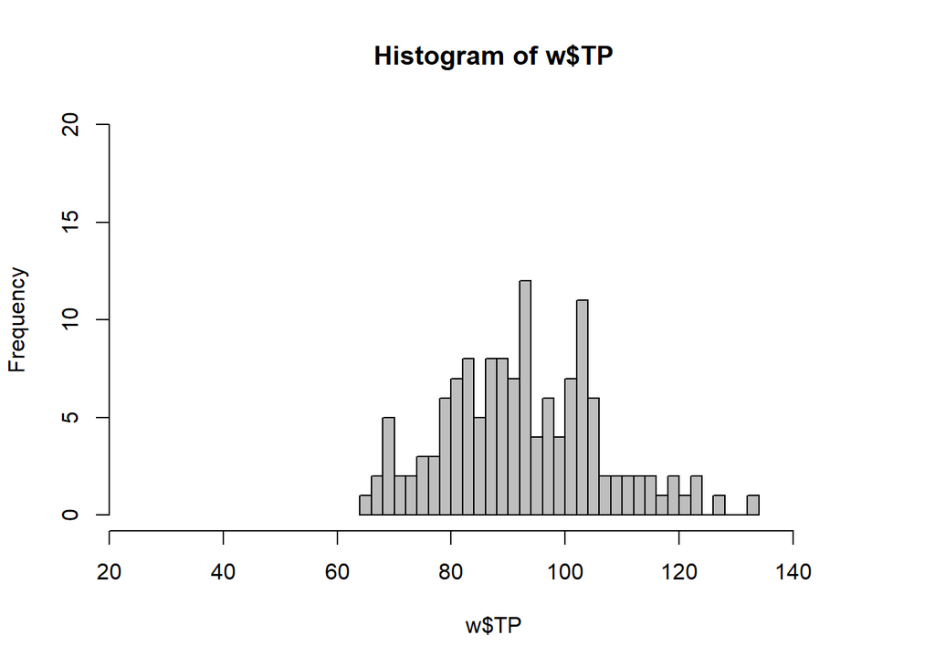

```r
w <- boxscores %>% filter(RESULT == "WIN")
l <- boxscores %>% filter(RESULT == "LOSS")
hist(w$TP,breaks = 30,xlim=c(25,150),ylim=c(0,20),col="gray")
```

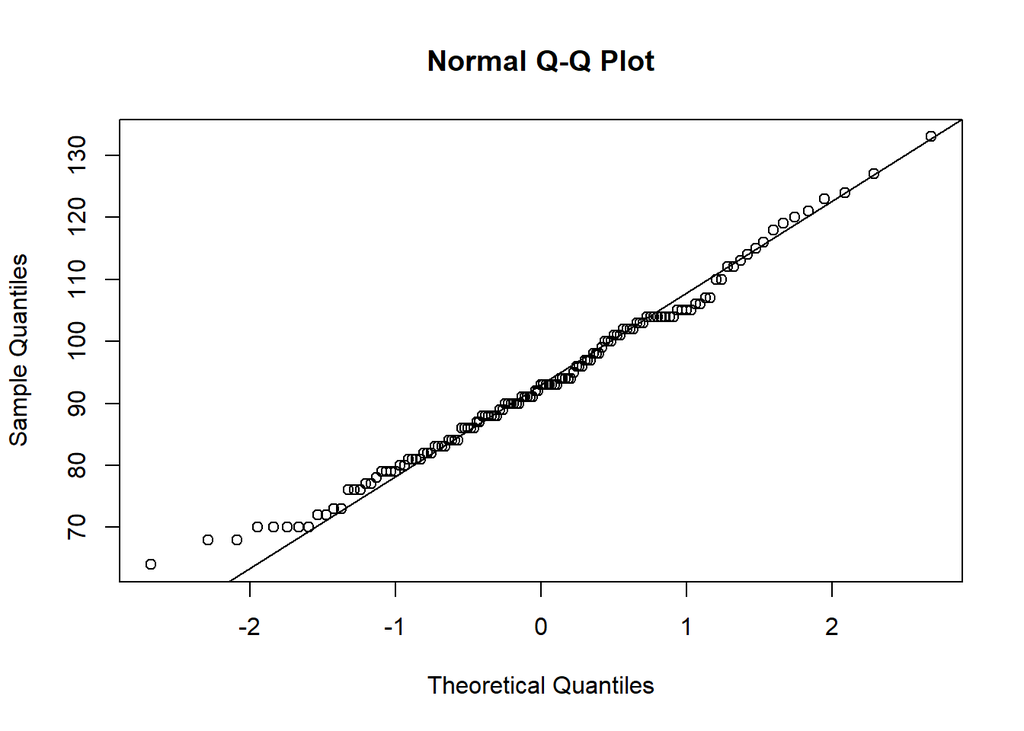

```r
qqnorm(w$TP)
qqline(w$TP)
```

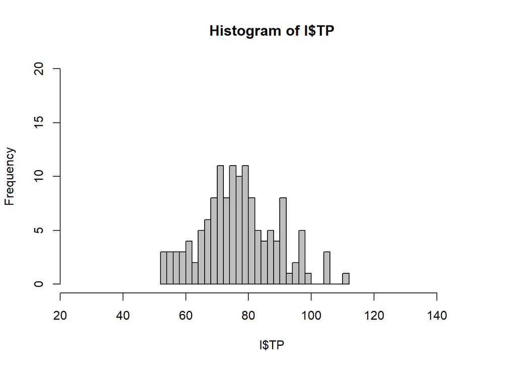

```r
hist(l$TP,breaks = 30,xlim=c(25,150),ylim=c(0,20),col="gray")
```

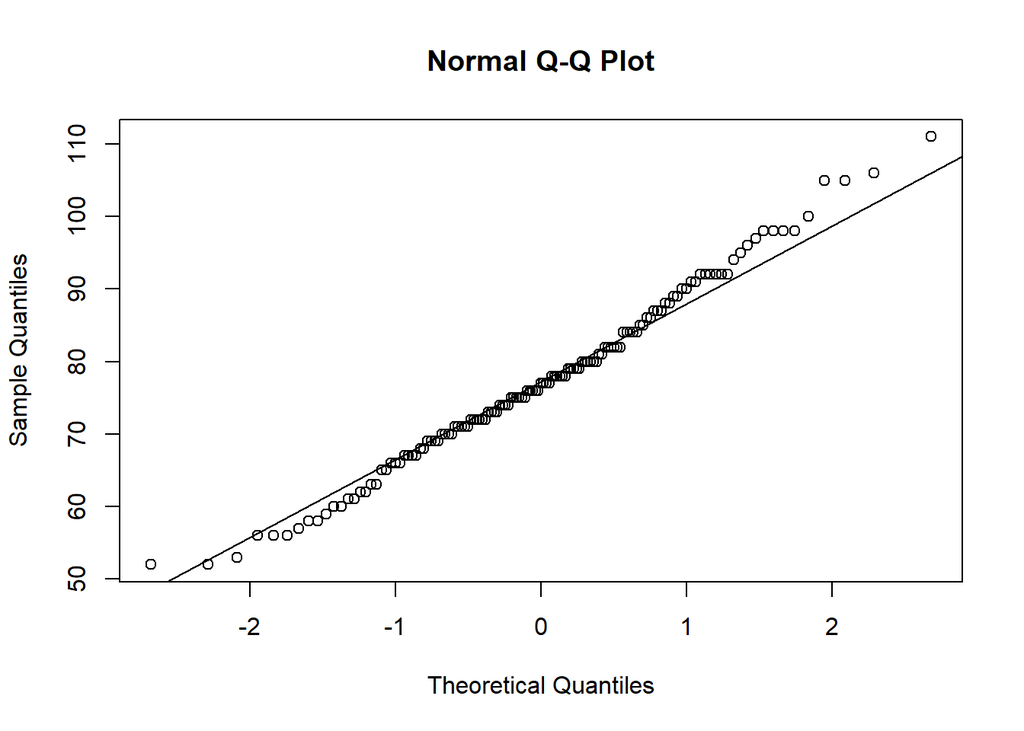

```r
qqnorm(l$TP)
qqline(l$TP)
```

```r
summary(w$TP)
```

```
##    Min. 1st Qu.  Median    Mean 3rd Qu.    Max.
##   64.00   83.00   93.00   93.16  103.00  133.00
```

```r
summary(l$TP)
```

```
##    Min. 1st Qu.  Median    Mean 3rd Qu.    Max.
##   52.00   70.00   77.00   77.33   84.50  111.00
```

The boxscores approximate normal distributions. We use inter quartile ranges to determine if any scores are outliers

```r
#win scores too high
w_quartiles <- quantile(w$TP)
upper_th <- w_quartiles[4] +
   1.5 * (w_quartiles[4] - w_quartiles[2])
houtliers <- sort(unique(w$TP[w$TP > upper_th]))
houtliers
```

```
## numeric(0)
```

```r
#lose scores too low
l_quartiles <- quantile(l$TP)
lower_th <- l_quartiles[2] -
   1.5 * (l_quartiles[4] - l_quartiles[2])
loutliers <- sort(unique(l$TP[w$TP < lower_th]))
loutliers
```

```
## numeric(0)
```

The above shows there are no statistically significant outliers in the data.

## Data pre-processing

To prepare a data frame with required numeric variables for analysis:

```r
#remove unneeded categorical variables and aggregate variables
boxscores.trim <- boxscores %>% select(-c(RND, TEAM, "3P%", "2P%", "FT%", TR, PTOS, PITP, "2CPS", MIN, TP)) %>%
#convert RESULT to a binomial variable
mutate(RESULT = ifelse(RESULT == "WIN", 1, 0))
#coerce to  a numeric data frame
boxscores.trim <- sapply(boxscores.trim, as.numeric)
```

## Feature selection

14 variables is too many, let’s look for key values ## Principal Component Analysis

```r
# remove response variable
boxscores.pca <- boxscores.trim[, 1:13]
res.pca <- PCA(boxscores.pca, graph = FALSE)
#note that the function 'PCA' automatically standardises the data
eig.val <- get_eigenvalue(res.pca)
eig.val
```

```
##        eigenvalue variance.percent cumulative.variance.percent
## Dim.1  2.64835955       20.3719965                    20.37200
## Dim.2  2.10321631       16.1785870                    36.55058
## Dim.3  1.90491894       14.6532226                    51.20381
## Dim.4  1.32002554       10.1540426                    61.35785
## Dim.5  1.13243983        8.7110756                    70.06892
## Dim.6  0.98108141        7.5467801                    77.61570
## Dim.7  0.90638694        6.9722072                    84.58791
## Dim.8  0.73240737        5.6339029                    90.22181
## Dim.9  0.48018435        3.6937257                    93.91554
## Dim.10 0.34330743        2.6408264                    96.55637
## Dim.11 0.24726778        1.9020598                    98.45843
## Dim.12 0.13150231        1.0115562                    99.46998
## Dim.13 0.06890225        0.5300173                   100.00000
```

An eigenvalue > 1 indicates that PCs account for more variance than accounted by one of the original variables in standardized data. This is commonly used as a cutoff point for which PCs are retained. This holds true only when the data are standardized. The function “PCA” does this automatically.

In this case, 5 dimensions > 1 and cover 70% of the variance. An alternative method to determine the number of principal components is to look at a Scree Plot, which is the plot of eigenvalues ordered from largest to the smallest. The number of component is determined at the point, beyond which the remaining eigenvalues are all relatively small and of comparable size

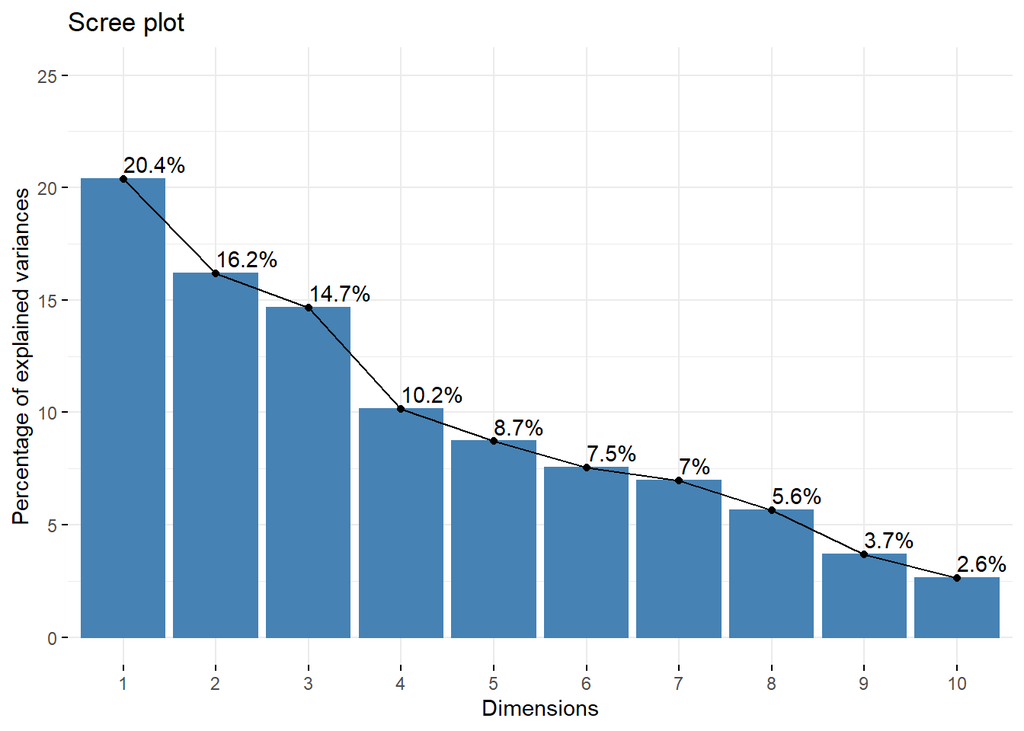

```r
fviz_screeplot(res.pca, addlabels = TRUE, ylim = c(0, 25))
```

5 dimensions still looks right. The quality of representation of the variables is called cos2 (square cosine, squared coordinates). You can visualize the cos2 of variables on all the dimensions using the corrplot package:

```r
var <- get_pca_var(res.pca)
var
```

```
## Principal Component Analysis Results for variables
##  ===================================================
##   Name       Description
## 1 "$coord"   "Coordinates for the variables"
## 2 "$cor"     "Correlations between variables and dimensions"
## 3 "$cos2"    "Cos2 for the variables"
## 4 "$contrib" "contributions of the variables"
```

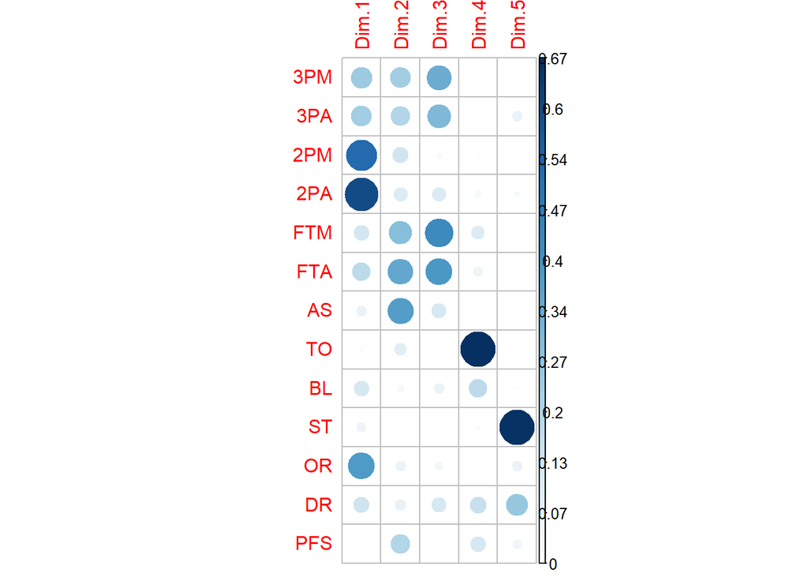

```r
corrplot(var$cos2, is.corr=FALSE)
```

It’s possible to use the function corrplot() to highlight the most contributing variables for each dimension:

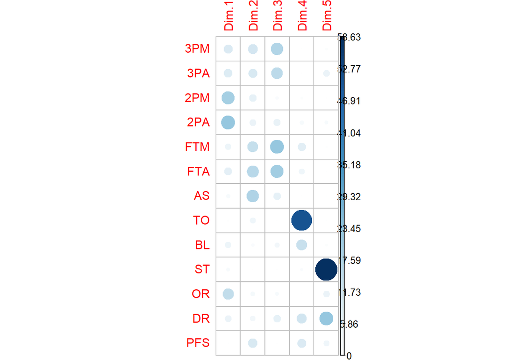

```r
corrplot(var$contrib, is.corr=FALSE)
```

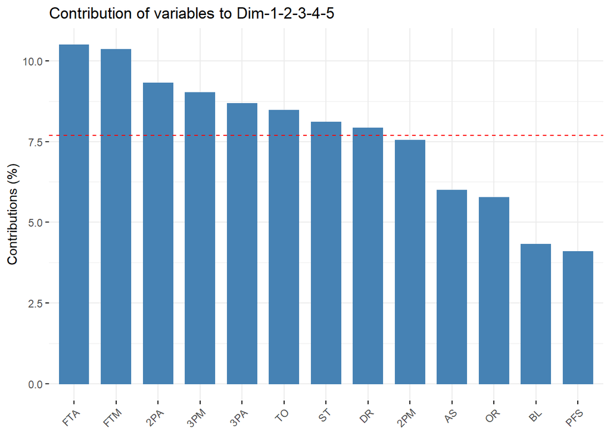

```r
#a visualisation
fviz_contrib(res.pca, choice = "var", axes = 1:5, top = 13)
```

The red dashed line on the graph above indicates the expected average contribution. If the contribution of the variables were uniform, the expected value would be 1/length(variables) = 1/13. For a given component, a variable with a contribution larger than this cutoff could be considered as important in contributing to the component. Although 2PM is below the cutoff, we will include it for practical reasons

```r
Boxscores <- boxscores.trim %>% subset(TRUE, c(1:6, 8, 10, 12, 14)) %>%
data.frame()
summary(Boxscores)
```

```
##       X3PM             X3PA            X2PM            X2PA
##  Min.   : 2.000   Min.   :12.00   Min.   :10.00   Min.   :26.00
##  1st Qu.: 6.000   1st Qu.:22.00   1st Qu.:19.00   1st Qu.:45.00
##  Median : 8.000   Median :27.00   Median :23.00   Median :51.00
##  Mean   : 7.996   Mean   :27.23   Mean   :23.73   Mean   :51.16
##  3rd Qu.:10.000   3rd Qu.:31.75   3rd Qu.:28.00   3rd Qu.:57.00
##  Max.   :20.000   Max.   :50.00   Max.   :44.00   Max.   :73.00
##       FTM            FTA              TO              ST
##  Min.   : 0.0   Min.   : 4.00   Min.   : 6.00   Min.   : 1.000
##  1st Qu.:10.0   1st Qu.:16.25   1st Qu.:14.00   1st Qu.: 7.000
##  Median :14.0   Median :22.00   Median :17.00   Median : 9.000
##  Mean   :13.8   Mean   :21.94   Mean   :17.12   Mean   : 9.515
##  3rd Qu.:18.0   3rd Qu.:27.00   3rd Qu.:20.00   3rd Qu.:12.000
##  Max.   :35.0   Max.   :49.00   Max.   :32.00   Max.   :23.000
##        DR            RESULT
##  Min.   :18.00   Min.   :0.0
##  1st Qu.:30.00   1st Qu.:0.0
##  Median :34.00   Median :0.5
##  Mean   :34.46   Mean   :0.5
##  3rd Qu.:39.00   3rd Qu.:1.0
##  Max.   :55.00   Max.   :1.0
```

## Machine Learning

```r
set.seed(88)
if (!interactive()) {
  lgr::get_logger("mlr3")$set_threshold("warn")
}
```

# Build a task

```r
#first make response variable a factor for classification purposes
Boxscores$RESULT <- as.factor(Boxscores$RESULT)
Boxscores_tsk <- TaskClassif$new(id = "Boxscores", backend = Boxscores, target = "RESULT", positive = "1")
Boxscores_tsk
```

```
## <TaskClassif:Boxscores> (270 x 10)
## * Target: RESULT
## * Properties: twoclass
## * Features (9):
##   - dbl (9): DR, FTA, FTM, ST, TO, X2PA, X2PM, X3PA, X3PM
```

# Define training(75%) and test(25%) sets

```r
train_set <- sample(Boxscores_tsk$nrow, 0.75 * Boxscores_tsk$nrow)
test_set <- setdiff(seq_len(Boxscores_tsk$nrow), train_set)
```

# Define a logistic regression learner

```r
# Check available learners
as.data.table(mlr_learners)
```

| key | feature_types | packages | properties | predict_types |
| --- | --- | --- | --- | --- |
| classif.debug |  |  |  |  |
| classif.featureless |  |  |  |  |
| classif.glmnet |  |  |  |  |
| classif.kknn |  |  |  |  |
| classif.lda |  |  |  |  |
| classif.log_reg |  |  |  |  |
| classif.naive_bayes |  |  |  |  |
| classif.qda |  |  |  |  |
| classif.ranger |  |  |  |  |
| classif.rpart |  |  |  |  |

[output cut: 11 more lines]

```r
#Define an mlr3 Learner
lrn <- lrn("classif.log_reg", predict_type = "prob") # shorter way
```

# Train the Learner on the Task

Train the previously defined learner on the `Boxscores_tsk` task.

```r
learner <- lrn$train(task = Boxscores_tsk, row_ids = train_set)
```

The learner now contains the trained model:

```r
class(lrn$model)
```

```
## [1] "glm" "lm"
```

```r
summary(lrn$model)
```

```
##
## Call:
## stats::glm(formula = task$formula(), family = "binomial", data = task$data())
##
## Deviance Residuals:
##      Min        1Q    Median        3Q       Max
## -2.02416  -0.25106   0.00711   0.31611   2.91663
##
## Coefficients:
##              Estimate Std. Error z value Pr(>|z|)
## (Intercept) -12.51433    3.73400  -3.351 0.000804 ***
## DR            0.50426    0.08554   5.895 3.74e-09 ***
## FTA          -0.14094    0.07727  -1.824 0.068144 .
## FTM           0.32503    0.11248   2.890 0.003858 **
## ST            0.51851    0.10683   4.853 1.21e-06 ***
## TO           -0.34165    0.07966  -4.289 1.79e-05 ***
## X2PA         -0.31618    0.05962  -5.303 1.14e-07 ***
## X2PM          0.57937    0.10238   5.659 1.52e-08 ***
## X3PA         -0.27226    0.06728  -4.047 5.20e-05 ***
## X3PM          0.58321    0.14934   3.905 9.41e-05 ***
## ---
## Signif. codes:  0 '***' 0.001 '**' 0.01 '*' 0.05 '.' 0.1 ' ' 1
##
## (Dispersion parameter for binomial family taken to be 1)
##
##     Null deviance: 279.71  on 201  degrees of freedom
## Residual deviance: 102.53  on 192  degrees of freedom
## AIC: 122.53
##
## Number of Fisher Scoring iterations: 7
```

### Make Predictions

Use the learner that now stores the model to predict the label on the `Boxscores.test` data.

```r
# Learner
pred <- lrn$predict(task = Boxscores_tsk, row_ids = test_set)
#confusion matrix
pred$confusion
```

```
##         truth
## response  1  0
##        1 29  5
##        0  1 33
```

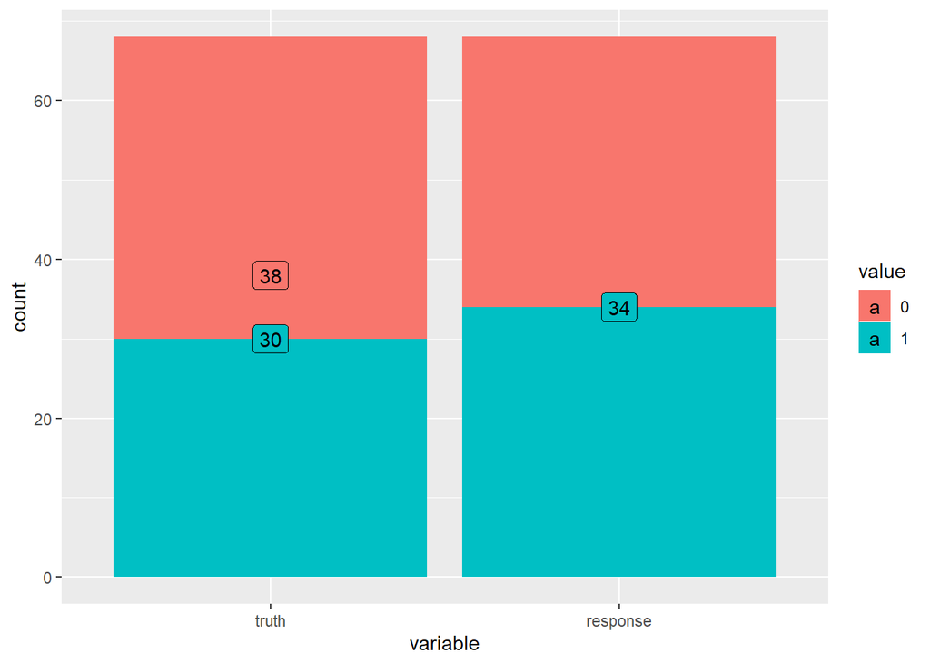

```r
autoplot(pred)
```

# choose different measures to score the prediction

```r
mlr_measures
```

```
## <DictionaryMeasure> with 51 stored values
## Keys: classif.acc, classif.auc, classif.bacc, classif.ce,
##   classif.costs, classif.dor, classif.fbeta, classif.fdr, classif.fn,
##   classif.fnr, classif.fomr, classif.fp, classif.fpr, classif.logloss,
##   classif.mcc, classif.npv, classif.ppv, classif.precision,
##   classif.recall, classif.sensitivity, classif.specificity, classif.tn,
##   classif.tnr, classif.tp, classif.tpr, debug, oob_error, regr.bias,
##   regr.ktau, regr.mae, regr.mape, regr.maxae, regr.medae, regr.medse,
##   regr.mse, regr.msle, regr.pbias, regr.rae, regr.rmse, regr.rmsle,
##   regr.rrse, regr.rse, regr.rsq, regr.sae, regr.smape, regr.srho,
##   regr.sse, selected_features, time_both, time_predict, time_train
```

```r
msrs = lapply(c("classif.auc", "classif.precision", "classif.recall"), msr)
pred$score(measures = msrs)
```

```
##       classif.auc classif.precision    classif.recall
##         0.9815789         0.8529412         0.9666667
```

## Resampling

To automate the test train split we can use resample. Therefore we need a resampling strategy.

```r
# show available resampling objects
mlr_resamplings
```

```
## <DictionaryResampling> with 6 stored values
## Keys: bootstrap, custom, cv, holdout, repeated_cv, subsampling
```

```r
# load cross validation
rds <- rsmp("cv")
# check how many folds
rds$param_set$values
```

```
## $folds
## [1] 10
```

We want to do a 10-fold cross-validation:

```r
# change the folds parameter of the resampling description object
rds$param_set$values$folds = 10

# execute resampling
res <- resample(task = Boxscores_tsk, learner = lrn, resampling = rds)

# calculate performance measures with previously defined measures
res$score(msrs)
```

| task | task_id | learner | learner_id | resampling | resampling_id | iteration | prediction | classif.auc | classif.precision | classif.recall |
| --- | --- | --- | --- | --- | --- | --- | --- | --- | --- | --- |
|  | Boxscores |  | classif.log_reg |  | cv | 1 |  | 0.9545455 | 0.9375000 | 0.9375000 |
|  | Boxscores |  | classif.log_reg |  | cv | 2 |  | 0.9615385 | 0.8461538 | 0.8461538 |
|  | Boxscores |  | classif.log_reg |  | cv | 3 |  | 0.9944444 | 0.9230769 | 1.0000000 |
|  | Boxscores |  | classif.log_reg |  | cv | 4 |  | 0.9395604 | 0.7857143 | 0.8461538 |
|  | Boxscores |  | classif.log_reg |  | cv | 5 |  | 1.0000000 | 0.9411765 | 1.0000000 |
|  | Boxscores |  | classif.log_reg |  | cv | 6 |  | 0.9715909 | 0.9000000 | 0.8181818 |
|  | Boxscores |  | classif.log_reg |  | cv | 7 |  | 0.9197531 | 0.9375000 | 0.8333333 |
|  | Boxscores |  | classif.log_reg |  | cv | 8 |  | 0.9890110 | 1.0000000 | 0.9285714 |
|  | Boxscores |  | classif.log_reg |  | cv | 9 |  | 0.8833333 | 0.8000000 | 0.6666667 |
|  | Boxscores |  | classif.log_reg |  | cv | 10 |  | 0.8705882 | 0.7272727 | 0.8000000 |

```r
res$aggregate(msrs)
```

```
##       classif.auc classif.precision    classif.recall
##         0.9484365         0.8798394         0.8676561
```

## Benchmarking

We are going to benchmark multiple classification learners on the task The benchmark will use the previously defined 10-fold cross-validation.

```r
# experiments with learners
design <- benchmark_grid(
  tasks = Boxscores_tsk,
  learners = lapply(c("classif.log_reg", "classif.kknn", "classif.ranger", "classif.xgboost", "classif.rpart"), lrn),
  resamplings = rds)

# conduct benchmark
res <- benchmark(design = design)
res
```

```
## <BenchmarkResult> of 50 rows with 5 resampling runs
##  nr   task_id      learner_id resampling_id iters warnings errors
##   1 Boxscores classif.log_reg            cv    10        0      0
##   2 Boxscores    classif.kknn            cv    10        0      0
##   3 Boxscores  classif.ranger            cv    10        0      0
##   4 Boxscores classif.xgboost            cv    10        0      0
##   5 Boxscores   classif.rpart            cv    10        0      0
```

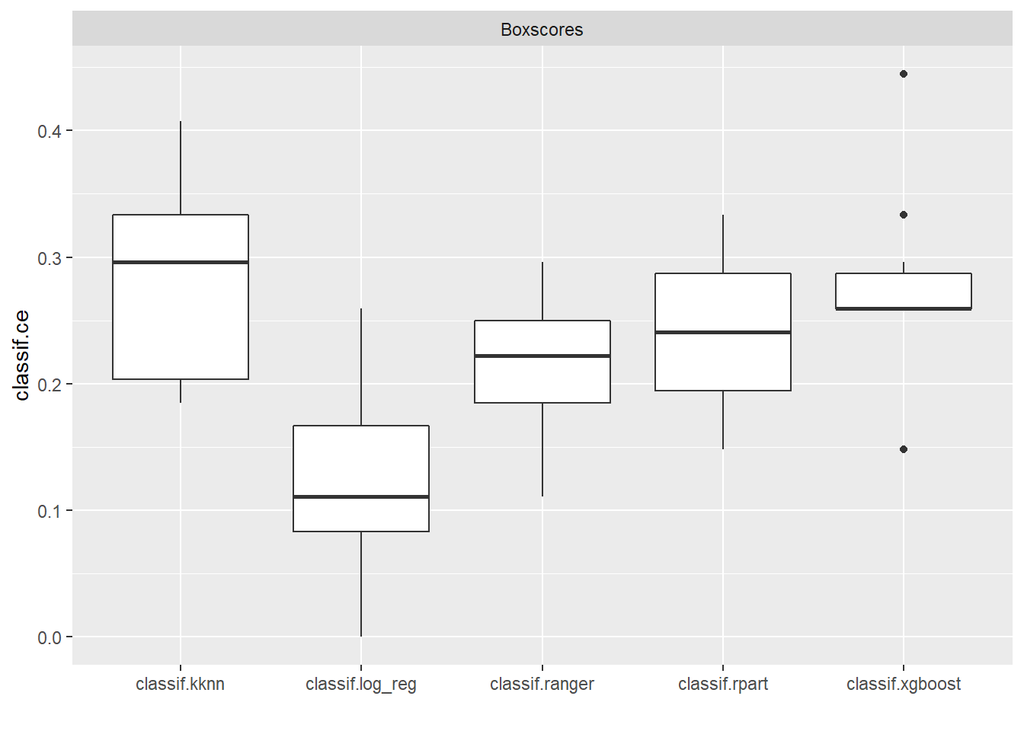

```r
# plot benchmark results
mlr3viz::autoplot(res)
```

The “log.reg” algorithm performs better than the other classification algortithms benchmarked.

Here is a function that predicts wina and loss given an input in the form: c(“DR”, “FTA”, “FTM”, “ST”, “TO”, “X2PA”, “X2PM”, “X3PA”, “X3PM”, “RESULT”)

As an example, c(28, 20, 14, 8, 12, 50, 25, 24, 8, 1) gives the result below:

```r
forecast <- function(x)  {
x <- as.data.frame(t(x))
names(x) <- c("DR", "FTA", "FTM", "ST", "TO", "X2PA", "X2PM", "X3PA", "X3PM", "RESULT")
x
x$RESULT <- as.factor(x$RESULT)
predict(learner, newdata = x, predict_type = "prob")
}
y <- c(28, 20, 14, 8, 12, 50, 25, 24, 8, 1)
forecast(y)
```

```
##              1         0
## [1,] 0.5477158 0.4522842
```